# Disease Mapping using INLA

Joaquín Martínez-Minaya

2026-04-01

# 1 Introduction

Disease mapping is a cornerstone of epidemiology, offering insights into the **spatial distribution of health risks**. Standardized Mortality Ratios (**SMRs**) are commonly used to quantify disease risks in specific regions, enabling comparisons across populations with varying sizes and demographic structures. Despite their utility, **SMRs can be misleading**, particularly in areas with small populations.

This document examines these challenges using **oral cancer mortality data** from the Valencian Region. We calculate SMRs, discuss their limitations, and explore alternative statistical approaches to improve risk estimation. All analyses and methodologies presented in this tutorial are inspired by Examples 4.2 and 4.5 from the book *Disease Mapping. From Foundations to Multidimensional Modeling* by Martínez-Beneito, M. and Botella, P.

# 2 Epidemiological Context

In epidemiology, the **Standardized Mortality Ratio (SMR)** is a widely used measure to assess the **relative risk of mortality** in a specific geographic area compared to a standard population. It is defined as:

$$\text{SMR}_i = \frac{O_i}{E_i} \times 100$$

Where:

- $O_i$: **Observed number of deaths** in area $i$.
- $E_i$: **Expected number of deaths** in area $i$, typically calculated based on the area’s population and age-specific mortality rates in a reference population.

**Interpretation**:

- **SMR = 100**: Risk is equivalent to the standard population.
- **SMR > 100**: Higher-than-expected mortality (**excess risk**).
- **SMR < 100**: Lower-than-expected mortality (**reduced risk**).

**SMRs adjust for population size and demographic composition**, making them valuable for identifying high- and low-risk areas. However, their **reliability decreases in small populations**, where variability can distort the estimates.

# 3 Oral Cavity Cancer in the Valencian Region

Oral cavity cancer is a significant public health concern due to its **serious impact on quality of life and survival rates**. In the Valencian Region, this disease has shown a **notable geographic disparity**, with some municipalities experiencing higher mortality rates than others. This variation necessitates a deeper understanding of the spatial distribution of risks to guide public health interventions effectively.

## 3.1 Case Description

This analysis focuses on **oral cavity cancer mortality data** collected across the municipalities of the Valencian Region. The dataset includes:

- **Observed deaths ($O_i$)**: Total number of deaths attributed to oral cavity cancer in each municipality over the study period.
- **Expected deaths ($E_i$)**: Estimated number of deaths based on population size and age-specific mortality rates from a standard reference population.
- **Population data**: To calculate expected deaths and evaluate the role of population size in shaping mortality patterns.

## 3.2 Key Observations

1. **Extreme SMRs in Small Municipalities**:  
   Small municipalities with low populations often display highly variable SMRs. For example:
   - **Castell de Cabres**: Despite a population of ~10 men, it recorded an SMR of **3977** due to a single observed death.
   - Similar patterns occur in other rural municipalities, highlighting the instability of SMRs in such areas.
2. **Spatial Patterns**:  
   Choropleth maps of SMRs reveal clusters of extreme values, particularly in rural areas. These clusters may not necessarily reflect genuine differences in disease risk but instead artifacts caused by population size variability.

## 3.3 Medical Objectives

The overarching goal of this analysis is to provide **accurate and interpretable estimates of disease risk** to inform public health decisions. Specifically:

1. **Identify High-Risk Areas**:  
   Highlight municipalities with genuinely elevated risks of oral cavity cancer to prioritize public health resources and interventions.
2. **Stabilize Risk Estimates**:  
   Develop robust statistical methods to reduce the **variability and bias** inherent in SMRs for small populations.
3. **Understand Geographic Disparities**:  
   Investigate whether rural municipalities genuinely exhibit higher or lower risks of oral cavity cancer and explore potential factors, such as environmental exposures or access to healthcare.
4. **Guide Public Health Policy**:  
   Use the findings to:
   - Design targeted prevention campaigns in high-risk areas.
   - Improve early detection and treatment programs.
   - Address potential healthcare inequities between rural and urban populations.

By addressing these objectives, we aim to produce a **reliable disease map** that accurately reflects the true spatial distribution of oral cavity cancer mortality in the Valencian Region. This is essential for ensuring that limited healthcare resources are allocated where they are most needed.

# 4 Choropleth Maps

This section visualizes the spatial distribution of **Standardized Mortality Ratios (SMR)** and **population** across the municipalities of the Valencian Region. These visualizations help identify areas of high and low disease risk and examine the relationship between population size and risk levels.

```r
# Read the spatial data (shapefile)
VR.sf <- st_read("Valencian_Region_Oral_Cancer.shp", quiet = TRUE)

# Check the structure of the spatial data
print(st_geometry(VR.sf))
```

```
## Geometry set for 540 features
## Geometry type: MULTIPOLYGON
## Dimension:     XY
## Bounding box:  xmin: 626680 ymin: 4191059 xmax: 815673.1 ymax: 4519371
## Projected CRS: ETRS89 / UTM zone 30N
## First 5 geometries:
```

```r
head(VR.sf)
```

```
## Simple feature collection with 6 features and 12 fields
## Geometry type: MULTIPOLYGON
## Dimension:     XY
## Bounding box:  xmin: 679680 ymin: 4225818 xmax: 761300 ymax: 4308321
## Projected CRS: ETRS89 / UTM zone 30N
##       AREA PERIMETER MUNI_ MUNI_ID CODMUNI CODPROV CODAUTO CODCOMAR   NOMBRE
## 1 14681063  18108.73  6985    6985   03001      03      12       10  Adsubia
## 2 66660673  38762.56  7241    7241   03002      03      12       05    Agost
## 3 25687710  20389.39  7058    7058   03003      03      12       07    Agres
## 4 18530322  19958.96  7222    7222   03004      03      12       09   Aigues
## 5 66620674  46345.56  7337    7337   03005      03      12       01 Albatera
## 6 14430581  20750.16  7067    7067   03006      03      12       14 Alcalali
##   Population Obs       Exp                       geometry
## 1        304   0 0.8974516 MULTIPOLYGON (((746539 4302...
## 2       2150   2 4.2089951 MULTIPOLYGON (((708180 4261...
## 3        344   2 0.8202787 MULTIPOLYGON (((713004 4298...
## 4        322   1 0.8158292 MULTIPOLYGON (((727482 4263...
## 5       4670  10 7.6222825 MULTIPOLYGON (((688868 4225...
## 6        552   2 1.8417344 MULTIPOLYGON (((755915 4290...
```

We now create a combined choropleth map: 1. **SMR Map**: Shows the spatial distribution of SMRs. 2. **Population Map**: Highlights population levels across municipalities.

Both maps are displayed side by side for comparison.

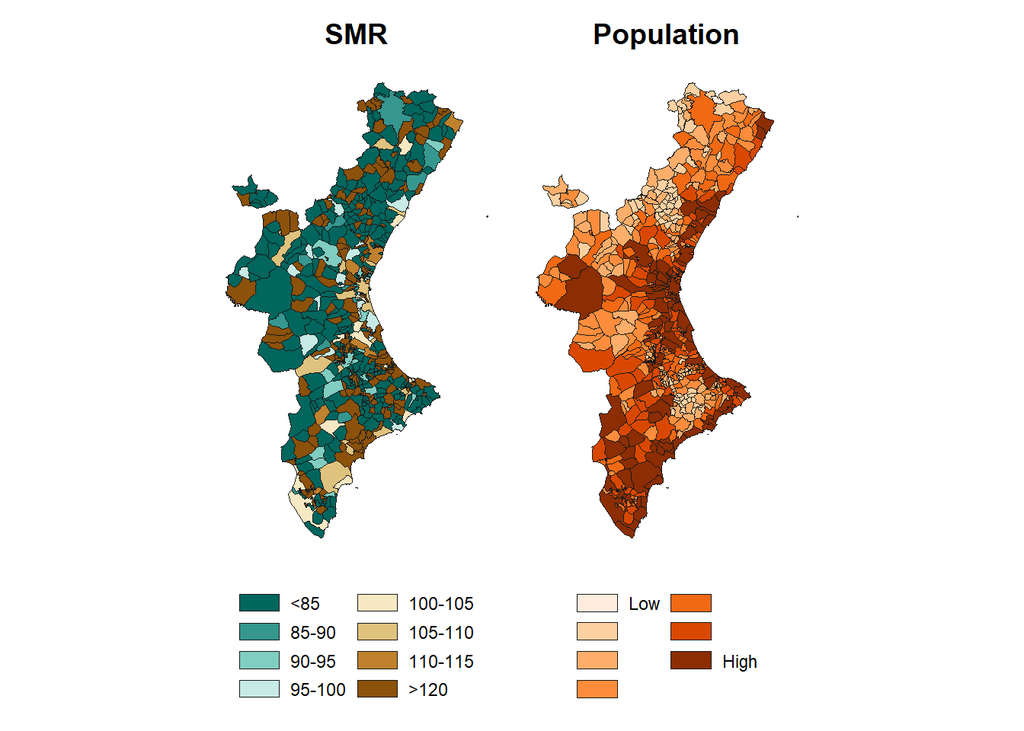

```r
# Prepare SMR and Population data
VR.sf <- VR.sf %>%
  mutate(
    SMR = 100 * Obs / Exp,
    cut_smr = cut(SMR,
                  breaks = c(-0.1, 85, 90, 95, 100, 105, 110, 115, 1e+07),
                  include.lowest = TRUE),
    cut_pop = cut(Population,
                  breaks = c(0, quantile(Population, probs = seq(0, 1, length.out = 7))),
                  include.lowest = TRUE)
  )


# SMR
colors_smr <- brewer.pal(8, "BrBG")[8:1]

# Create the ggplot map
smr_map <- ggplot(VR.sf) +
  geom_sf(aes(fill = cut_smr),
          color = "gray10", # Border color
          linewidth = 0.1) +  # Adjust border thickness
  scale_fill_manual(
    values = colors_smr,                                    # Use custom palette
    name = "SMR",                                           # Legend title
    labels = c("<85", "85-90", "90-95", "95-100", "100-105", "105-110", "110-115", ">120") # Custom legend labels
  ) +
  labs(title = "SMR") +      # Add title
  theme_minimal() +                                          # Clean theme
  theme(
    legend.position = "bottom",                             # Legend at bottom
    legend.key.width = unit(0.7, "cm"),                       # Adjust legend size
    legend.key.height = unit(0.3, "cm"),
    panel.grid = element_blank(),
        legend.title = element_blank(),
# Remove gridlines for cleaner map
    axis.text = element_blank(),                            # Remove axis text
    axis.ticks = element_blank(),                            # Remove axis ticks
    plot.title = element_text(hjust = 0.5, size = 14, face = "bold"), # Center and style the title
) +
  guides(fill=guide_legend(ncol=2))



# Population
# Define the color palette
colors_pop <- brewer.pal(7, "Oranges")

# Create the ggplot map
population_map <- ggplot(VR.sf) +
  geom_sf(aes(fill = cut_pop), color = "gray10",  linewidth = 0.01)+   # Map `fill` to `cut_pop`, gray borders
  scale_fill_manual(
    values = colors_pop,                                    # Use custom palette
    name = "Population",                                    # Legend title
    labels = c("Low", "", "", "", "", "", "High")           # Custom legend labels
  ) +
  labs(title = "Population") +
  theme_minimal() +                                    # Clean theme
   theme(
         panel.grid = element_blank(),                           # Remove gridlines for cleaner map
    axis.text = element_blank(),                            # Remove axis text
    axis.ticks = element_blank(),
    legend.title = element_blank(),
    legend.position = "bottom",                             # Legend at bottom
    legend.key.width = unit(0.7, "cm"),                       # Adjust legend size
    legend.key.height = unit(0.3, "cm"),                     # Adjust legend height
    plot.title = element_text(hjust = 0.5, size = 14, face = "bold"), # Center and style the title

  ) +
  guides(fill=guide_legend(ncol=2))


smr_map + population_map
```

# 5 Small Areas

Small areas often present challenges in disease mapping due to the **statistical instability of SMRs**. Castell de Cabres, a municipality in the Valencian Region with a population of only ~10, is a clear example.

```r
VR.sf %>%
  filter(SMR> 500) %>%
  arrange(desc(SMR)) %>%
  select(NOMBRE, Population, Obs, SMR) %>%
  as.data.frame(.) %>%
  select(-geometry) %>%
  knitr::kable(.)
```

| NOMBRE | Population | Obs | SMR |
| --- | --- | --- | --- |
| Castell de Cabres | 10 | 1 | 3977.4449 |
| Todolella | 86 | 3 | 1152.5204 |
| Torrella | 87 | 2 | 1021.2520 |
| Balones | 75 | 2 | 887.9789 |
| Olocau del Rey | 84 | 2 | 856.5711 |
| Villores | 38 | 1 | 706.4548 |
| Estubeny | 70 | 1 | 553.1380 |
| Ayodar | 124 | 2 | 500.9707 |

This extreme value arises from the combination of a **small population** and a **single observed death**. Such cases highlight the **volatility of SMRs** in low-population areas.

If Castell de Cabres had recorded **no deaths** ($O_i = 0$), then SMR = 0. This illustrates how SMRs in small areas can swing from extreme highs to the lowest possible value, not due to true changes in risk but because of random variability.

The implications are:

- **Unreliable Estimates**: SMRs in small areas are sensitive to single events, often leading to misleading patterns.
- **Bias in Resource Allocation**: High SMRs in small populations may draw attention away from areas with genuine risk.
- **Need for Stabilization**: Bayesian smoothing or hierarchical models are necessary to account for the uncertainty in small areas.

These challenges underscore the importance of **contextualizing SMRs** in disease mapping and exploring alternative approaches to estimate risks in small areas reliably.

# 6 Defining Neighbor Relations

In spatial analysis, defining neighbor relations is essential for modeling spatial dependencies. This section demonstrates how to define and visualize neighbor relationships for the municipalities in the Valencian Region.

## 6.1 3.1 Creating the Neighbor Graph

We first define the neighbor relationships using `poly2nb` from the `spdep` package and create a graph file compatible with **INLA**.

```r
# Create neighbor relationships
temp <- poly2nb(VR.sf)
```

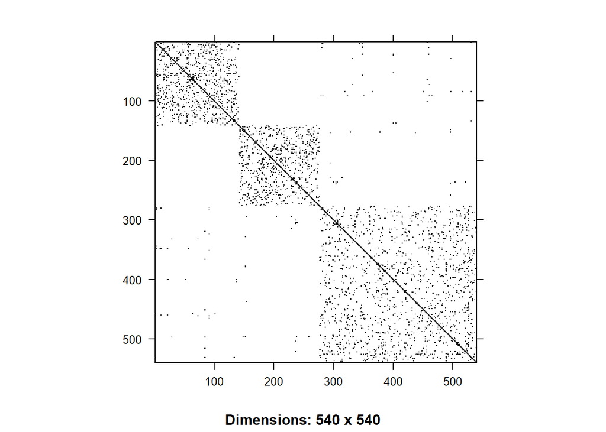

```r
# Save the neighbor graph for INLA
nb2INLA("VR.graph", temp)

# Load the graph into INLA
H <- inla.read.graph(filename = "VR.graph")

# Visualize the adjacency matrix of the graph
image(inla.graph2matrix(H), xlab = "", ylab = "")
```

## 6.2 3.2 Visualizing Neighbor Relationships

To better understand the spatial structure of the Valencian Region, we plot the neighbors of selected municipalities using a custom function.

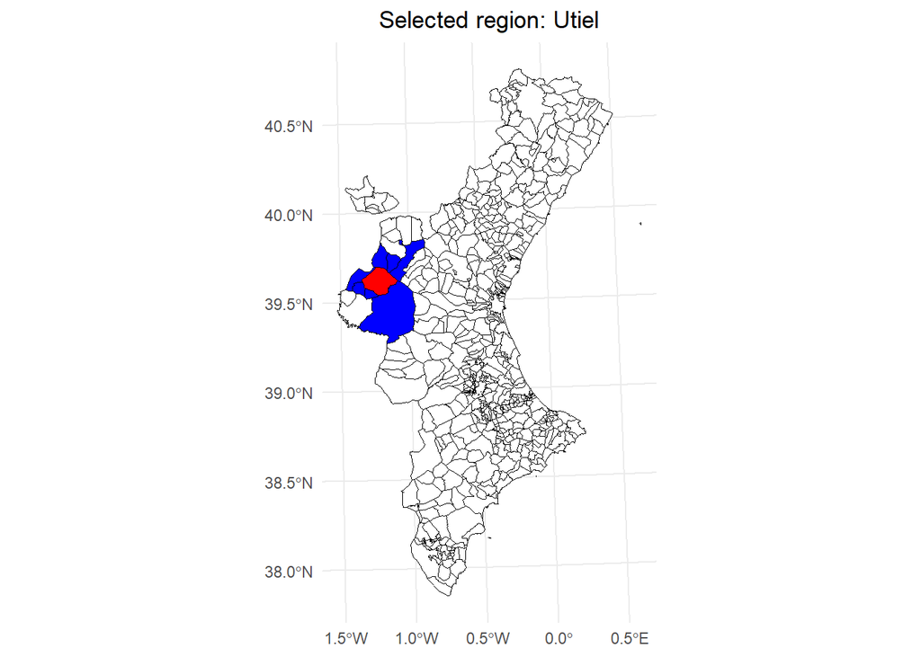

```
## You have selected Utiel and its neighbors are:
## Benageber Camporrobles Caudete de las Fuentes Chelva Fuenterrobles Requena Sinarcas
```

```r
# Function to visualize neighbors on the map
plot_map_neig_ggplot <- function(neig, VR.sf, temp) {
  # Base map of the Valencian Region
  p <- ggplot() +
    geom_sf(data = VR.sf, fill = "white", color = "black") +                    # Base map
    geom_sf(data = VR.sf[neig, ], fill = "red", color = "black") +              # Selected region
    geom_sf(data = VR.sf[temp[[neig]], ], fill = "blue", color = "black") +     # Neighbor regions
    theme_minimal() +
    ggtitle(paste("Selected region:", VR.sf$NOMBRE[neig])) +                    # Title
    theme(plot.title = element_text(hjust = 0.5))                              # Center the title

  # Print the plot
  print(p)

  # Print neighbor information
  cat("You have selected", VR.sf$NOMBRE[neig], "and its neighbors are:", "\n")
  cat(VR.sf$NOMBRE[temp[[neig]]], "\n")
}

# Example: Plot neighbors for selected municipalities
plot_map_neig_ggplot(neig = 525, VR.sf, temp = temp)
```

# 7 Fitting a Model with a BYM Effect

This section demonstrates how to fit a model with spatial and unstructured random effects using the **Besag-York-Mollié (BYM)** model. The spatial random effects account for neighboring relationships, while the unstructured effects capture independent variability.

## 7.1 Model Description

In this analysis, we use a **Poisson regression model** with spatially structured and unstructured random effects to model the disease risk in the Valencian Region. The Poisson distribution is particularly well-suited for modeling **count data**, such as the number of observed cases, and it is ideal for analyzing the **Standardized Mortality Ratio (SMR)** because it directly relates observed and expected cases, adjusting for population differences across areas.

1. **Likelihood**:
   The observed number of cases ($O_i$) in each area $i$ follows a **Poisson distribution**:
   $$O_i \sim \text{Poisson}(\lambda_i), \quad \lambda_i = E_i \rho_i,$$
   where:
   - $E_i$ is the expected number of cases, derived from the population size and age-specific rates in a standard population,
   - $\rho_i$ is the relative risk, modeled on the log scale as:
     $$\log(\rho_i) = \eta_i.$$
2. **Linear Predictor**:
   The linear predictor $\eta_i$ captures both spatial and non-spatial variability:
   $$\eta_i = \beta_0 + u_i + v_i,$$
   where:
   - $\beta_0$ is the intercept, representing the baseline log-risk,
   - $u_i$ is the **independent random effect**, accounting for uncorrelated variability specific to each area,
   - $v_i$ is the **spatially structured random effect**, capturing correlation between neighboring areas.
3. **Random Effects**:
   - **Independent Effect ($u_i$)**:
     Modeled as independent and identically distributed:
     $$u_i \sim \mathcal{N}(0, \tau_u^{-1}),$$
     where $\tau_u$ is the precision of the random effect.
   - **Spatial Effect ($v_i$)**:
     Modeled conditionally on its neighbors:
     $$v_i \mid \{v_j : j \sim i\} \sim \mathcal{N}\left(\frac{1}{n_i} \sum_{j \sim i} v_j, \frac{1}{n_i \tau_v}\right),$$
     where $n_i$ is the number of neighbors for area $i$, and $\tau_v$ is the precision of the spatial random effect.
4. **Hyperparameters**:
   The standard deviation parameters $\sigma_u$ and $\sigma_v$ follow uniform priors:
   $$\sigma_u, \sigma_v \sim \text{Uniform}(0, \infty).$$

## 7.2 Adding IDs for Random Effects

To define spatial and independent random effects, we assign unique IDs for each municipality:

```r
VR.sf <- VR.sf %>%
  mutate(S = as.numeric(row_number())) # Unstructured effect IDs
```

## 7.3 Defining the Formula

```r
sdunif="expression:
logdens=-log_precision/2;
return(logdens)"

formula <- Obs ~ 1 +
  f(S,
    model = "bym",
    graph = H,
    scale.model = TRUE,
    hyper=list(prec.spatial=list(prior=sdunif),
prec.unstruct=list(prior=sdunif)))
```

## 7.4 Fitting the Model

We fit the model using INLA, specifying the Poisson family for the observed counts and including the expected counts (`E`) as an offset.

```r
mod.disease <- inla(formula,
                    family = "poisson",
                    data = VR.sf,
                    E = Exp,
                    control.compute = list(dic = TRUE, waic = TRUE, cpo = TRUE),
                    control.predictor = list(compute = TRUE, cdf = c(log(1))))
summary(mod.disease)
```

```
## Time used:
##     Pre = 0.402, Running = 1.16, Post = 0.321, Total = 1.88
## Fixed effects:
##               mean    sd 0.025quant 0.5quant 0.975quant   mode kld
## (Intercept) -0.048 0.024     -0.096   -0.047     -0.001 -0.047   0
##
## Random effects:
##   Name     Model
##     S BYM model
##
## Model hyperparameters:
##                                        mean      sd 0.025quant 0.5quant
## Precision for S (iid component)     1582.56 5430.16      58.00   471.01
## Precision for S (spatial component)   64.77   40.41      18.98    54.72
##                                     0.975quant   mode
## Precision for S (iid component)       10120.77 126.43
## Precision for S (spatial component)     170.89  39.74
##
## Deviance Information Criterion (DIC) ...............: 1775.14
## Deviance Information Criterion (DIC, saturated) ....: 546.81
## Effective number of parameters .....................: 36.67
##
## Watanabe-Akaike information criterion (WAIC) ...: 1771.30
## Effective number of parameters .................: 28.80
##
## Marginal log-Likelihood:  -657.27
## CPO, PIT is computed
## Posterior summaries for the linear predictor and the fitted values are computed
## (Posterior marginals needs also 'control.compute=list(return.marginals.predictor=TRUE)')
```

## 7.5 Posterior Distribution of SMR

We calculate the posterior mean, standard deviation, median, and credible intervals for SMRs. Additionally, we assess the probability that the SMR is greater than 1.

```r
VR.sf <- VR.sf %>%
  mutate(SMR_mean = mod.disease$summary.fitted.values$mean,
         SMR_sd = mod.disease$summary.fitted.values$sd,
         SMR_median = mod.disease$summary.fitted.values$`0.5quant`,
         SMR_q025 = mod.disease$summary.fitted.values$`0.025quant`,
         SMR_q975 = mod.disease$summary.fitted.values$`0.975quant`,
         SMR_p1 = 1 - mod.disease$summary.fitted.values$`1cdf`)
```

## 7.6 Visualizing SMRs with Cutoffs

We categorize and map the SMR means and probabilities.

[figure not shown]

```r
SMR.cutoff <- c(-0.1, 85, 90, 95, 100, 105, 110, 115, 1e+07)
SMR_p1.cutoff <- c(0, 0.2, 0.6, 0.8, 1)

VR.sf <- VR.sf %>%
  mutate(SMR_disc = cut(SMR_mean*100, breaks = SMR.cutoff, include.lowest = TRUE,
                        labels = c("<85", "85-90", "90-95", "95-100", "100-105", "105-110", "110-115", ">120")),
         SMR_p1_disc = cut(SMR_p1, breaks = SMR_p1.cutoff, include.lowest = TRUE))



SMR_fitted <- ggplot(VR.sf) +
  geom_sf(aes(fill = SMR_disc),
          color = "gray10", # Border color
          linewidth = 0.1) +  # Adjust border thickness
  scale_fill_manual(
    values = colors_smr,                                    # Use custom palette
    name = "SMR",                                           # Legend title
    labels = c("<70", "70-90", "90-95", "95-100", "100-105", "105-110", "110-130", ">130"),
    drop = FALSE
  )+
  labs(title = "SMR") +      # Add title
  theme_minimal() +                                          # Clean theme
  theme(
    legend.position = "bottom",                             # Legend at bottom
    legend.key.width = unit(0.7, "cm"),                       # Adjust legend size
    legend.key.height = unit(0.3, "cm"),
    plot.title = element_text(hjust = 0.5, size = 14, face = "bold"), # Center and style the title

    panel.grid = element_blank(),
        legend.title = element_blank(),
# Remove gridlines for cleaner map
    axis.text = element_blank(),                            # Remove axis text
    axis.ticks = element_blank()                            # Remove axis ticks
  ) +
  guides(fill=guide_legend(ncol=2))
smr_map | SMR_fitted
```

The comparison between the original and the adjusted SMR maps highlights the benefits of using hierarchical Bayesian models in disease mapping. While the original SMR map shows high variability, especially in areas with smaller populations, the adjusted SMR map provides smoothed estimates, reducing the impact of random fluctuations caused by small population sizes. This stabilization allows for a more reliable interpretation of spatial risk patterns and better-informed public health interventions.

# 8 Posterior Predictive Distribution for the Risk

This section focuses on estimating the **posterior predictive distribution** of the relative risk ($\rho_i$), defined as:

$$p(\rho_i \mid \mathbf{y}),$$

where $\rho_i = \lambda_i / E_i$ represents the relative risk, $\lambda_i$ is the true underlying rate, and $E_i$ is the expected number of cases.

By calculating $p(\rho_i \mid \mathbf{y})$, we smooth the observed risks ($y_i / E_i$), accounting for uncertainty in areas with small populations or low case counts. This allows us to identify regions with genuinely elevated risks, reducing the impact of random noise and supporting informed public health decisions.

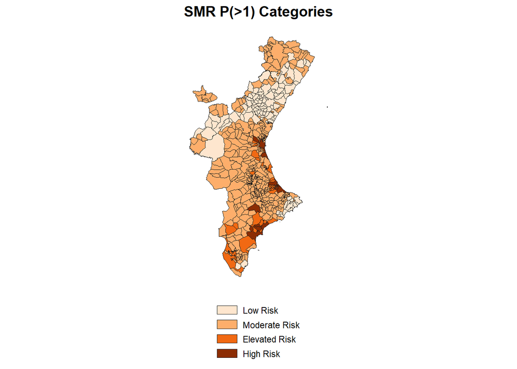

```r
# Plotting SMR Probability > 1

# Define custom labels for the categories
custom_labels <- c("Low Risk", "Moderate Risk", "Elevated Risk", "High Risk")

colors_SMR_risk <- brewer.pal(8, "Oranges")[seq(2, 8, by  = 2)]


# Update SMR_disc2
SMR_disc2 <- ggplot(data = VR.sf) +
  geom_sf(aes(fill = SMR_p1_disc),
          color = "gray10", # Border color
          linewidth = 0.1) +  # Adjust border thickness
  scale_fill_manual(
    values = colors_SMR_risk,  # Custom palette for 4 categories
    name = "SMR Risk Levels",                                       # Legend title
    labels = custom_labels,                                         # Custom labels
    drop = FALSE                                                    # Include unused levels
  ) +
  labs(title = "SMR P(>1) Categories") +                            # Add title
  theme_minimal() +                                                 # Clean theme
  theme(
    legend.position = "bottom",                                     # Legend at bottom
    legend.key.width = unit(0.7, "cm"),                             # Adjust legend size
    legend.key.height = unit(0.3, "cm"),
    plot.title = element_text(hjust = 0.5, size = 14, face = "bold"), # Center and style the title
    panel.grid = element_blank(),
    legend.title = element_blank(),                                 # Remove legend title
    axis.text = element_blank(),                                    # Remove axis text
    axis.ticks = element_blank()                                    # Remove axis ticks
  ) +
  guides(fill = guide_legend(ncol = 1))                             # Two-column legend

# Display the updated plot
print(SMR_disc2)
```

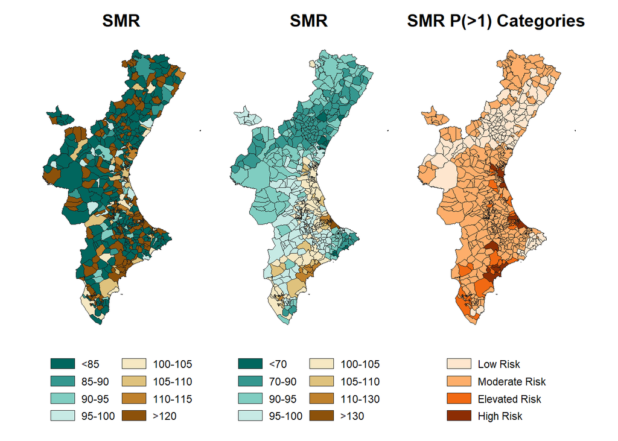

```r
smr_map | SMR_fitted | SMR_disc2
```

## 8.1 Interactive Map of SMR

Finally, we create an interactive map using `leaflet` for better exploration.

```r
VR.sf <- st_transform(VR.sf, crs = 4326)  # Transform CRS for leaflet
pal <- colorNumeric(palette = "YlOrRd", domain = VR.sf$SMR_median)

leaflet(VR.sf) %>%
  addTiles() %>%
  addPolygons(color = "white", fillColor = ~pal(SMR_median),
              fillOpacity = 1, weight = 0.5) %>%
  addLegend(pal = pal, values = ~SMR_median, opacity = 0.8, title = "SMR Median")
```

[interactive chart not shown]